# Лабораторная работа № 2

## Гамма-спектрометр на основе сцинтилляционного счетчика

### Кафедра физики ускорителей

Вероника Бояркина, Вячеслав Федоров, Анна Шуклина

## Теория

### Принцип действия сцинтилляционного счётчика

- Заряженная частица, проходя через сцинтиллятор, помимо ионизации атомов и молекул, возбуждает их.
- Возвращаясь в невозбуждённое (основное) состояние, атомы испускают фотоны с энергией видимого, ближнего ультрафиолетового или инфракрасного диапазонов (сцинтилляция или радиолюминесценция).
- Фотоны, попадая на катод ФЭУ, выбивают электроны, которые усиливаются внутри ФЭУ, в результате чего на аноде возникает электрический импульс, который дополнительно усиливается и регистрируется электроникой.
- Детектирование нейтральных частиц (нейтронов, γ-квантов) происходит по вторичным заряженным частицам (электроны, позитроны, ядра отдачи и осколки расщепленных ядер), образующимся при взаимодействии нейтронов и γ-квантов с атомами сцинтиллятора.

### ФЭУ

Фотоэлектронный умножитель — это электровакуумный прибор, в котором для преобразования светового потока в поток электронов в вакууме используют внешний фотоэффект, а число электронов умножается за счёт эффекта вторичной эмиссии

### Сцинтилляторы

Время высвечивания характеризует продолжительность световой вспышки сцинтиллятора 𝐼(𝑡)=𝐼_0 exp(−𝑡/𝜏) τ — время высвечивания, в течение которого интенсивность падает в e раз

### Органические сцинтилляторы

Малый атомный номер (ZC = 6, ZH = 1), небольшая плотность (около 1 г/см3 ) и небольшая эффективность поглощения γ-квантов. Они применяются для регистрации заряженных частиц. Наиболее высокой конверсионной эффективностью обладают сцинтилляторы, содержащие ароматические соединения. Органические сцинтилляторы могут быть подразделены на три широких класса: кристаллы, пластики и жидкости. Кристаллы, такие как антрацен, стильбен и нафталин очень прочны и имеют довольно высокий световыход, но их люминесцентное излучение анизотропно, что ухудшает в определенных ситуациях энергетическое разрешение. Жидкие сцинтилляторы — раствор одного или нескольких флюоресцирующих веществ (p-терфенил, (b-)PBD, PPO и др.) в органическом растворителе (толуол, ксилол, бензол, декалин и т.п.). Также в растворитель могут быть добавлены спектросмещающие добавки (POPOP, bis-MSB, BBQ и др.) для лучшего согласования излучения со спектральной чувствительностью фотодетектора.

•Пластические сцинтилляторы — раствор флюоресцентных добавок, который после полимеризации образует твердое вещество. В качестве полимерной основы чаще всего используют поливинилтолуол (ПВТ) или полистирол. •В органических сцинтилляторах отдельные молекулы слабо взаимодействуют друг с другом, то есть энергетические уровни отдельных молекул практически не возмущены присутствием соседних молекул. Поэтому можно считать, что характер взаимодействия заряженных частиц с веществом органического сцинтиллятора не зависит от его агрегатного состояния и сводится к ионизации и возбуждению отдельных молекул непосредственно заряженной частицей. Механизм сцинтилляций в органических материалах можно описать как последовательная передача энергии возбуждения от молекул основы к первичным центрам флуоресценции и затем к последующим центрам с постепенным понижением энергии излучаемых фотонов.

### Сцинтилляционный счётчик как гамма-спектрометр

Гамма-спектрометр — прибор, измеряющий энергию γ-квантов Состоит из детектора γ-квантов (сцинтилляционного счётчика), линейного усилителя и амплитудного анализатора импульсов (ЗЦП или АЦП) Гамма-спектрометр должен иметь достаточно большую эффективность полного поглощения энергии γ-кванта и хорошее энергетическое разрешение. Для эффективного полного поглощения γ-кванта на небольшой длине в сцинтилляционных спектрометрах применяют неорганические кристаллы высокой плотности и с большим атомным номером элементов, входящих в их состав. Чтобы гамма-спектрометр имел хорошее энергетическое разрешение сцинтиллятор должен иметь высокий световыход, а счётчик в целом — высокую практическую эффективность и хорошую однородность светосбора.

### Эффективность гамма-спектрометра

см. формулы в методичке

### Энергетическое разрешение гамма-спектрометра

см. формулы в методичке

### Установка

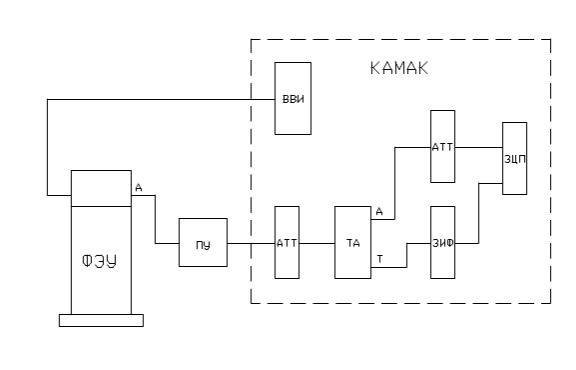

1 фотоэлектронный умножитель ФЭУ-143, 2 высоковольтный источник B0308 (ВВИ), 3 время-амплитудный блок (ТА), 4 аттенюаторы — 2 блока A0608 (АТТ), 5 блок ЗИФ D0302 (линия задержки + формирователь импульсов), 6 зарядово-цифровой преобразователь C0312 (ЗЦП), 7 сцинтилляторы в светоотражающей обертке с одной открытой гранью: NaI(Tl), ор- тогерманат висмута (BGO), пластический сцинтиллятор (на основе ПВТ), 8 радиоактивный изотоп 137Cs.

### Программное обеспечение

ROOT

## Задания

1. Убедиться, что кожух ФЭУ завинчен, чтобы наружный свет не попадал на фотока- тод.
2. Запустить управляющую программу. Установить напряжение питания ФЭУ равное 1300 В.
3. При небольшом ослаблении (3+3 db) набрать амплитудный спектр импульсов темнового тока фотоумножителя и определить центр тяжести полученного распределения.

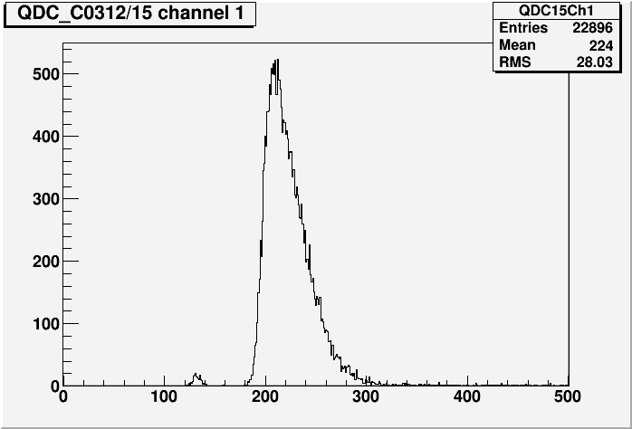

4. При том же значении ослабления откалибровать положение пьедестала, для чего набрать амплитудный спектр при значении задержки в первом канале ЗИФ равной 50 мкс, при этом ворота ЗЦП будут не совпадать по времени с сигналом. Центр тя- жести спектра даст амплитуду, соответствующую пьедесталу. Пьедестал необходимо учитывать при определении амплитуды сигнального спектра.

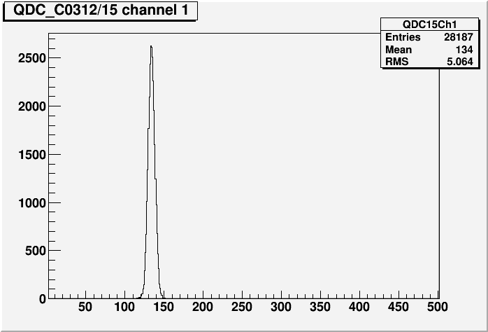

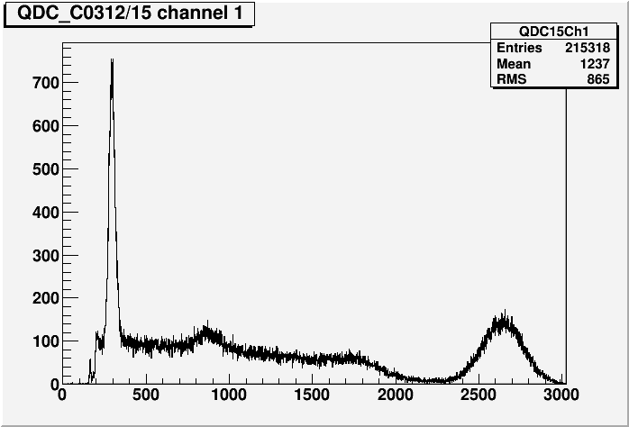

Не меняя ослабление, откалибровать пьедестал, как описано в п.4, и учесть его при вычислении амплитуд.

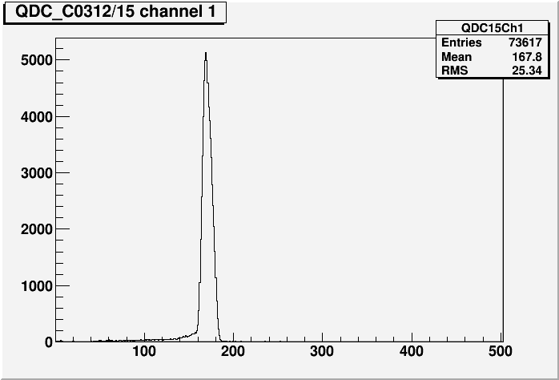

7. Аналогично получить спектры импульсов для BGO и пластического сцинтиллятора. Для BGO измерить положение пика полного поглощения и ПШПВ, а для пласти- ческого сцинтиллятора — положение края спектра комптоновских электронов. Для обоих спектров откалибровать и учесть пьедестал.

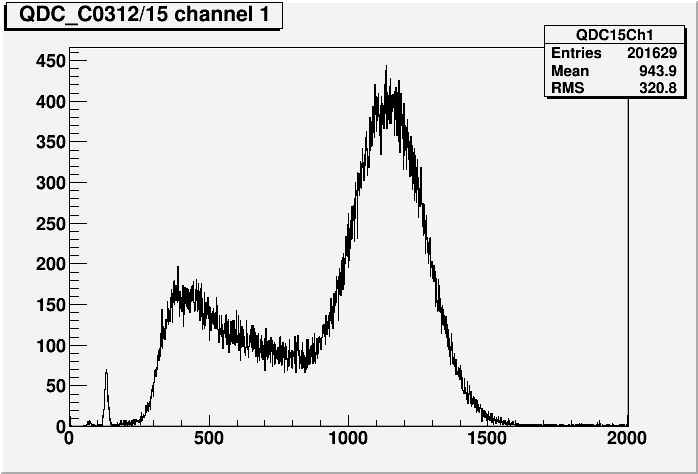

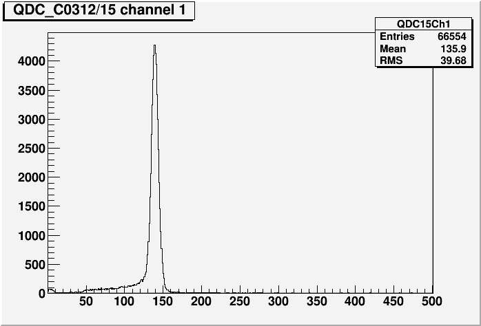

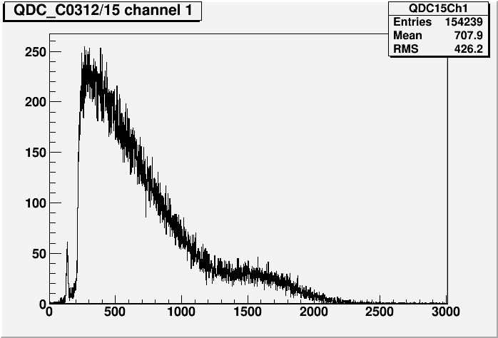

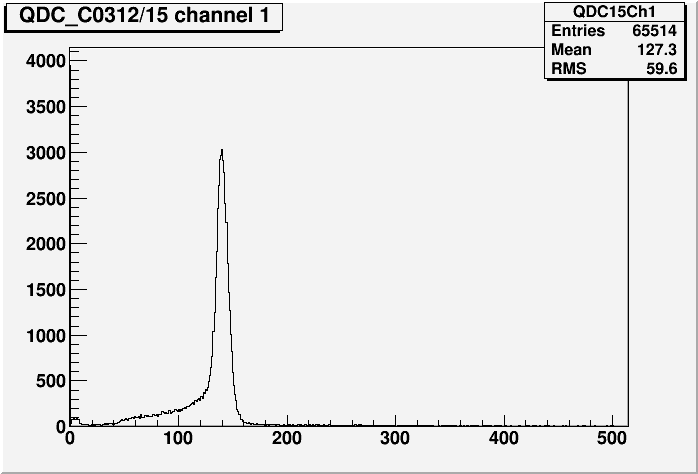

8. Закончив измерения, не забудьте убрать изотоп 137Cs в свинцовый домик!

## Обработка и представление результатов

1. Для отчета необходимо иметь распечатанные амплитудные спектры темнового тока ФЭУ, сцинтилляционного счетчика с NaI(Tl), BGO, пластическим сцинтиллятором.

```python
import pandas as pd
```

```python
columns = ['amplitude', 'scintillator', 'channel', 'width', 'attenuation']
data_df = pd.DataFrame([[0, 'dark current', 224-134, 40,  3+3],
                  [662, 'NaI', 2638-167, 300,  21+18],
                  [184, 'NaI', 850-167, 300, 21+18],
                  [662, 'BGO', 1136-135, 300,  21+3],
                  [662, 'plastic', 1571-127, 300, 21+3],
                  [478, 'plastic', 300-127, 500,  21+3]],
                  columns=columns)
```

```python
data_df['number'] = data_df['channel']/10**(-data_df['attenuation']/20)
data_df['energy'] = data_df['amplitude']/data_df['number']
```

```python
data_df
```

|  | amplitude | scintillator | channel | width | attenuation | number | energy |
| --- | --- | --- | --- | --- | --- | --- | --- |
| 0 | 0 | dark current | 90 | 40 | 6 | 179.573608 | 0.000000 |
| 1 | 662 | NaI | 2471 | 300 | 39 | 220228.106813 | 0.003006 |
| 2 | 184 | NaI | 683 | 300 | 39 | 60872.439075 | 0.003023 |
| 3 | 662 | BGO | 1001 | 300 | 24 | 15864.780857 | 0.041728 |
| 4 | 662 | plastic | 1444 | 300 | 24 | 22885.857699 | 0.028926 |
| 5 | 478 | plastic | 173 | 500 | 24 | 2741.865223 | 0.174334 |

3. Определить энергетическое разрешение ∆E/E сцинтилляционного счетчика с кри- сталлом NaI(Tl) и с BGO. ∆E — полная ширина на половине высоты пика полного поглощения в кэВ, E = 662 кэВ.

```python
data_df['resolution'] = data_df['width']/data_df['channel']
```

```python
data_df
```

|  | amplitude | scintillator | channel | width | attenuation | number | energy | resolution |
| --- | --- | --- | --- | --- | --- | --- | --- | --- |
| 0 | 0 | dark current | 90 | 40 | 6 | 179.573608 | 0.000000 | 0.444444 |
| 1 | 662 | NaI | 2471 | 300 | 39 | 220228.106813 | 0.003006 | 0.121408 |
| 2 | 184 | NaI | 683 | 300 | 39 | 60872.439075 | 0.003023 | 0.439239 |
| 3 | 662 | BGO | 1001 | 300 | 24 | 15864.780857 | 0.041728 | 0.299700 |
| 4 | 662 | plastic | 1444 | 300 | 24 | 22885.857699 | 0.028926 | 0.207756 |
| 5 | 478 | plastic | 173 | 500 | 24 | 2741.865223 | 0.174334 | 2.890173 |

## Вопросы

см. методичку